# Chapter 5

```r
library(tidyr); library(dplyr); library(ggplot2); library(corrplot); library(GGally);
human<-read.csv(file="Human.csv", header=T, sep=",")
dim(human)
```

```
## [1] 155   9
```

```r
rownames(human)<-human$X
human<-dplyr::select(human, -X)
```

*For some reason it gives me the names as a column again, so they have to be removed again for ggpairs to work.*

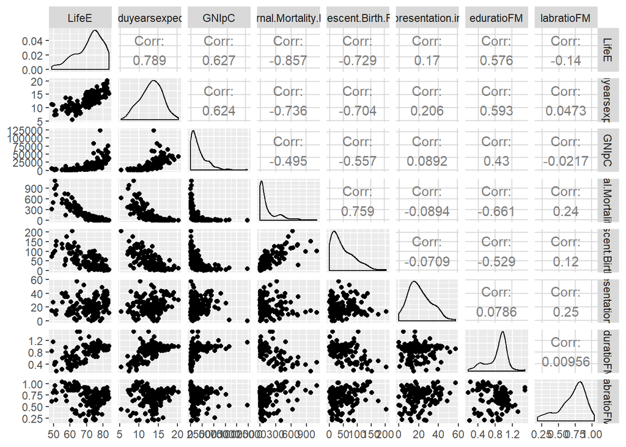

```r
ggpairs(human)
```

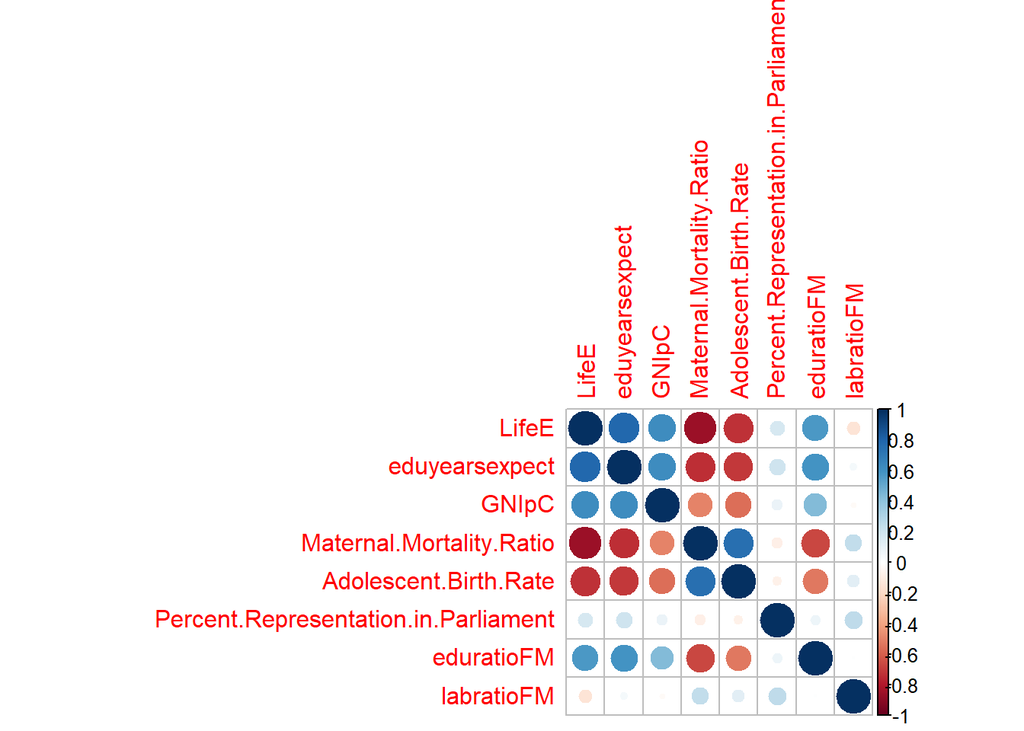

```r
cor(human)%>%corrplot()
```

*The data represents basic human development metrics such as life expectancy and average education, and shows relationships between these variables. The plots show us, among other things, that countries with many adolescent births also have significantly higher maternal mortality rates and lower life expectancies, and that countries where women receive more similar levels of education to men generally have better education as a whole and don’t have as many adolescent births. The better educated countries with higher life expectancies also have higher GNIs per capita, which can probably be expected.*

```r
pca_human<-prcomp(human)
pca_human
```

```
## Standard deviations (1, .., p=8):
## [1] 1.854416e+04 1.855219e+02 2.518701e+01 1.145441e+01 3.766241e+00
## [6] 1.565912e+00 1.912052e-01 1.591112e-01
##
## Rotation (n x k) = (8 x 8):
##                                                PC1           PC2
## LifeE                                -2.815823e-04 -0.0283150248
## eduyearsexpect                       -9.562910e-05 -0.0075529759
## GNIpC                                -9.999832e-01  0.0057723054
## Maternal.Mortality.Ratio              5.655734e-03  0.9916320120
## Adolescent.Birth.Rate                 1.233961e-03  0.1255502723
## Percent.Representation.in.Parliament -5.526460e-05 -0.0032317269
## eduratioFM                           -5.607472e-06 -0.0006713951
## labratioFM                            2.331945e-07  0.0002819357
##                                                PC3           PC4
## LifeE                                -1.294971e-02  6.752684e-02
## eduyearsexpect                       -1.427664e-02  3.313505e-02
## GNIpC                                 5.156742e-04 -4.932889e-05
## Maternal.Mortality.Ratio             -1.260302e-01  6.100534e-03
## Adolescent.Birth.Rate                 9.918113e-01 -5.301595e-03
## Percent.Representation.in.Parliament  7.398331e-03  9.971232e-01
## eduratioFM                            3.412027e-05  2.736326e-04
## labratioFM                           -5.302884e-04  4.692578e-03
##                                                PC5           PC6
## LifeE                                 0.9865644425  1.453515e-01
## eduyearsexpect                        0.1431180282 -9.882477e-01
## GNIpC                                -0.0001135863  2.711698e-05
## Maternal.Mortality.Ratio              0.0266373214 -1.695203e-03
## Adolescent.Birth.Rate                 0.0188618600 -1.273198e-02
## Percent.Representation.in.Parliament -0.0716401914  2.309896e-02
## eduratioFM                           -0.0022935252 -2.180183e-02
## labratioFM                            0.0022190154 -3.264423e-02
##                                                PC7           PC8
## LifeE                                -5.380452e-03  2.281723e-03
## eduyearsexpect                        3.826887e-02  7.776451e-03
## GNIpC                                 8.075191e-07 -1.176762e-06
## Maternal.Mortality.Ratio             -1.355518e-04  8.371934e-04
## Adolescent.Birth.Rate                 8.641234e-05 -1.707885e-04
## Percent.Representation.in.Parliament  2.642548e-03  2.680113e-03
## eduratioFM                           -6.998623e-01  7.139410e-01
## labratioFM                           -7.132267e-01 -7.001533e-01
```